# Giant Pumpkins Weight Prediction Report

# Summary

This project is an attempt to build a prediction model using regression based machine learning models to estimate the weight of giant pumpkins based on their features such as year of cultivation, place, and over the top(ott) size in order to predict the next year’s winner of the GP competition. Different regression based prediction models such as Linear, Ridge and Random Forest were used for training and cross-validation on the training data. For the Ridge model, the hyperparameter ($\alpha$) was optimised to return the best cross validation score. This model performed fairly well in predicting on the test data which led us to finalise the use of the model for prediction. The best score on cross validation sets is 0.6666134 and the mean test score is 0.6619808. The Random Forest model had similar cross-validation and test scores, but due to its high fit times, it was not chosen for this report. Therefore, for the purpose of reproducibility, we have decided to utilise the Ridge model as our prediction model. For better performance and precision, other models may also be tried on the data.

# Introduction

The data set used in this project is originally from [GPwebsite](http://www.bigpumpkins.com/Default.asp). The Great Pumpkin Commonwealth’s (GPC) mission promotes the hobby of cultivating giant pumpkins throughout the world through standards and regulations to ensure quality of fruit, fairness of competition, recognition of achievement, fellowship and education for all participating growers and weigh-off sites. (Read more [here](https://gpc1.org/) and [here](http://www.bigpumpkins.com/)).

In 1979, a Nova Scotia farmer named Howard Dill happened to grow a particularly large pumpkin. He decided to bring it to a fair near Philadelphia that was holding a weigh-off, his 438.5-pound vegetable won first place. This brief summary brings us to our prediction question to determine if we are able to predict pumpkin weights for the following year.

Giant pumpkin growing is a surprisingly competitive hobby as the right seeds can command huge prices. There is even a prize pool of $30,000 if you break the world record (1,226 kg). Everyone dreams of a spot in “the Super Bowl of pumpkin weigh-offs.”

So let’s test a model to estimate whether within the next year farmers can break the record or not.

Base on the data gathered by bigpumpkins website, the ott (over the top) is the most important feature for estimating the weight which is shown in Figure 1.

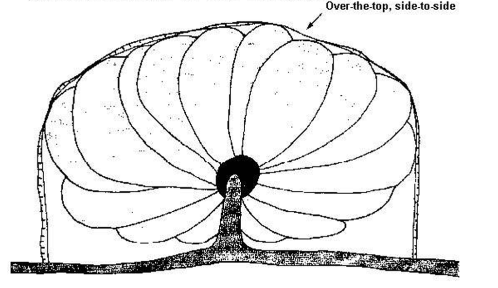

Figure 1. Over the top Measurement of Giant Pumpkin

# Data

The data used for this project comes from [BigPumpkins.com](http://www.bigpumpkins.com/ViewArticle.asp?id=132).

The dataset is a public domain resource which pertains to the attributes of giant pumpkins grown in around 20 countries across the world in different regions. The raw data which was used in this project for the analysis can be found [here](https://raw.githubusercontent.com/rfordatascience/tidytuesday/master/data/2021/2021-10-19/pumpkins.csv) from (Mock 2021).

Table 1 below shows the description of the data and its attributes:

## Data dictionary

| **variable** | **class** | **description** |
| --- | --- | --- |
| id | character | Year-type |
| place | character | Place/ranking |
| weight_lbs | character | Weight in pounds |
| grower_name | character | Name of grower |
| city | character | City |
| state_prov | character | State/Province |
| country | character | Country |
| gpc_site | character | GPC site (great pumpkin commonwealth) |
| seed_mother | character | Seed mother |
| pollinator_father | character | Father |
| ott | character | Over the top inches, can be used to estimate weight |
| est_weight | character | Estimated weight in lbs |
| pct_chart | character | Percent on chart |
| variety | character | Variety of pumpkin |

Types: F = “Field Pumpkin,” P = “Giant Pumpkin,” S = “Giant Squash,” W = “Giant Watermelon,” L = “Long Gourd” (length in inches, not weight in pounds), T = Tomato

Table 1 : Data Dictionary

Data description adapted from [here](https://github.com/rfordatascience/tidytuesday/blob/master/data/2021/2021-10-19/readme.md).

## Summary of raw data

- There are a total of about 28000 observations out of which about 15000 observations are of the type ‘P’ pertaining to Giant Pumpkins variety which is our subject of interest here.
- The raw data is of char type and needs to be converted suitably into numeric and character types for feature preparation.
- Some cleaning and preprocessing will be required for columns like `id` (separation of year and type), which contains information to be used in the prediction model.

# EDA

We have used Altair (VanderPlas et al. 2018) to generate the visualization for our EDA.

## Distribution Plots

The distribution plots in Figure 2 below are created to visualize the distribution of the weight_lbs (target) and the selected features.

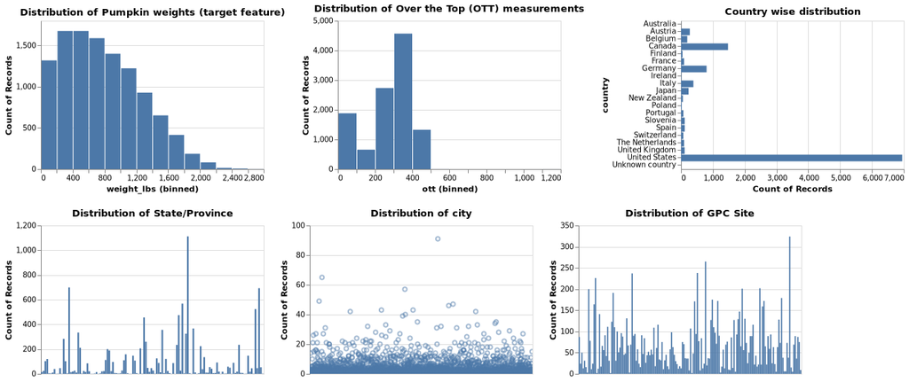

Figure 2. Distribution Plots of Giant Pumpkin Weight and selected features

We have concluded the following findings from the above plots.

- The majority weight of the giant pumpkins is between 0-1200lbs and the distribution is right-skewed. Therefore, in case imputation is needed, our strategy would not be filling the missing values with mean.
- Most of the giant pumpkins samples are from the United States and Canada which is reasonable based on the introduction that we have explained.
- There are more samples coming from particular locations (state/province, city and GPC site).

## Pairwise Relationship with Prediction Target (Weight)

We have visualized the relationship between the giant pumpkin weight and the features we think relevant to the growth of giant pumpkins, including ott, country, city, state/province and GPC site.

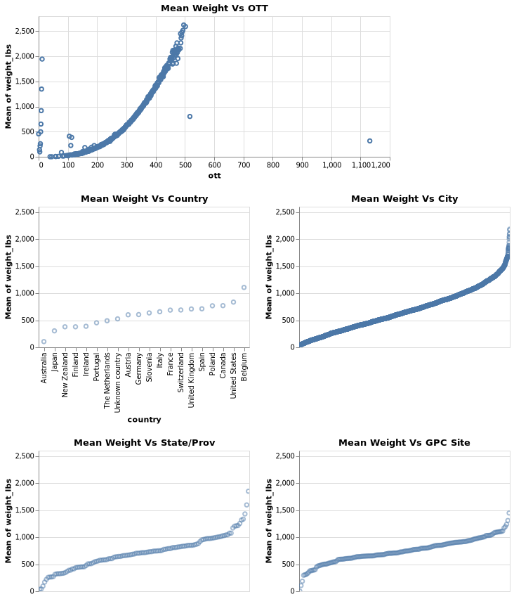

Figure 3. Pairwise Relationship of Giant Pumpkin Weight and selected features

# Analysis

The Python programming language (“Python Package Index - PyPI” n.d.) and the following packages were used to perform the analysis: Altair(VanderPlas et al. 2018), SKlearn (Pedregosa et al. 2011) and knitr (Xie 2021).

The majority of the raw data is composed of features with the character data type whilst others are numeric features. Some categorical features such as `country`, `state_prov` and `city` contain information relating to the origin of the pumpkin and where it was grown. Others numeric features such as `year` stores which year the pumpkin was grown and `ott` is the “over-the-top” measurement of the giant pumpkin size. We have chosen features that we believe they may impact the weight of a pumpkin whilst dropping other features that we deem irrelevant. We do think `seed_mother`, and `pollinator_father` features contain genetic information which would have an impact on the pumpkin size. However, the data quality in these two features are low as a fairly high percentage of data do not conform with the convention suggested (’ weight seed year’) and we are not able to extract the genetic information we want, thus we decided to drop these features.

An initial data cleaning, preparation and pre-processing was required to ready the data for training purposes. The dataset was split with a 70/30 split for the training and test sets respectively along with random seeding for reproducibility.

For the numeric features, we used a simple imputer to insert the ‘median’ value for any missing or Null values as well as a standard scaler via a pipeline. For categorical features, we similarly used a simple imputer but instead of filling in values with the mean, we filled them in with the value ‘missing.’ We then used one hot encoding to encode the categorical features.

The Ridge model was used to build and predict the weight (lbs) of a giant pumpkin given certain features from the dataset. The model was created using the train dataset, combined with the features we spoke about earlier, and the actual given weights of particular giant pumpkins.

Cross-validation is carried out to for hyperparameter tuning. We have used the `GridSearchCV` to find the optimized value of `alpha` in the Ridge model.

# Results and Discussion

We report the result with the default scoring metric of Ridge, $R^2$.

We found the optimized `alpha` value of our Ridge model be 1. In doing so, we were able to achieve a cross validation score of 0.6666134.

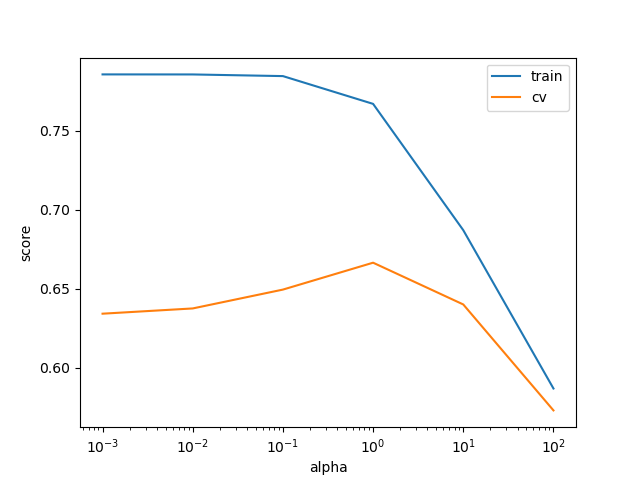

Figure 4. Hyperparameter Tuning for Ridge

Our prediction model performed decently well on the test data as well. The testing score we obtained with the testing set is 0.6619808. Below graph shows the plot of the predicted weight (lbs) vs actual weight (lbs) from the testing data set.

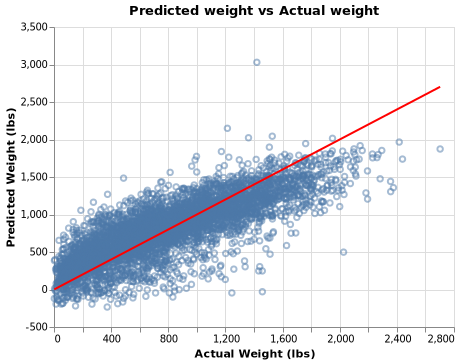

Figure 5. Prediction weights vs Actual weights

## Feature Importance

Table 2 below shows features with the largest coefficients (top 5) and smallest coefficients (bottom 5). There are 9 out of 10 features are from the city feature. Therefore, we can conclude that city (location) has the greatest impact in our weight prediction model.

Table 2 : Feature Importance by Top 5 and Bottom 5 Coefficients

| Features | Coefficients |
| --- | --- |
| city_Lloydminster | 964.78 |
| gpc_site_OO Landesgartenschau 2017 Kremsmunster | 717.74 |
| city_Pleasant Hill | 716.49 |
| city_Radda in Chianti | 697.23 |
| city_Boscawen | 649.13 |
| city_York | -433.44 |
| city_Lisbon | -424.04 |
| city_Goffston | -386.92 |
| city_Hudson | -386.05 |
| city_New Gloucester | -382.15 |

## Critique, Limitations and Future Improvements

We faced several limitations in our analysis such as limited types of features available for feature engineering and modelling. In addition, many features had to be discarded due to their lack of relevance to our model.

Future studies on this subject can be improved with the inclusion of more relevant predictive features, such as using the seed/genetic data of the father and mother, and more data. Additionally, further data cleaning methods could also be applied, such as inspection and removal of outliers, as these can affect regression model performance significantly.

We were able to create a more accurate model with Random Forest to predict weights of giant pumpkins but have opted to use the Ridge model instead. We have chosen to do so as the Random Forest model required upwards of 5 hours to run which we believe to be impractical and as such have decided to use a slightly less accurate but a much faster model. Thus, in the future, it could be worth looking into using alternative regression models that may provide accurate and timely results.

# Reference

Mock, Thomas. 2021. “Tidy Tuesday: A Weekly Data Project Aimed at the r Ecosystem.” https://github.com/rfordatascience/tidytuesday.

Pedregosa, Fabian, Gaël Varoquaux, Alexandre Gramfort, Vincent Michel, Bertrand Thirion, Olivier Grisel, Mathieu Blondel, et al. 2011. “Scikit-Learn: Machine Learning in Python.” *Journal of Machine Learning Research* 12 (Oct): 2825–30.

“Python Package Index - PyPI.” n.d. Python Software Foundation. Accessed March 28, 2021. https://pypi.org/.

VanderPlas, Jacob, Brian Granger, Jeffrey Heer, Dominik Moritz, Kanit Wongsuphasawat, Arvind Satyanarayan, Eitan Lees, Ilia Timofeev, Ben Welsh, and Scott Sievert. 2018. “Altair: Interactive Statistical Visualizations for Python.” *Journal of Open Source Software* 3 (32): 1057.

Xie, Yihui. 2021. *Knitr: A General-Purpose Package for Dynamic Report Generation in r*. https://yihui.org/knitr/.